# **Project Name** - Global Terrorism Analysis using EDA

##### **Project Type** - EDA (Exploratory Data Analysis)

##### **Contribution** - Individual/Team

##### Team Member - Dhruv chauhan

# **Project Summary -**

The Global Terrorism Analysis project focuses on performing an in-depth Exploratory Data Analysis (EDA) on the UNGTA dataset, which contains over 180,000 terrorist incidents recorded globally between 1970 and 2017. The objective of this project is to uncover patterns, trends, and insights related to terrorist activities across different regions, time periods, and attack types.

The dataset provides comprehensive information including date of attack, geographical location (country, region, city), type of attack, weapons used, target type, casualties, and responsible groups. Using powerful Python libraries such as Pandas, NumPy, Matplotlib, and Seaborn, the dataset is cleaned, processed, and visualized to extract meaningful insights.

Various visualizations are created to understand trends such as the rise in terrorist attacks over the years, the most affected regions and countries, the most common attack types, and the relationship between weapon types and casualties. The project also explores which terrorist groups are most active and which targets are most frequently attacked.

Key insights include identifying peak periods of terrorist activity, regions with the highest impact, and patterns in attack strategies. These insights can help policymakers, defense organizations, and global security agencies make data-driven decisions to prevent and mitigate terrorist threats.

Overall, this project demonstrates strong data analysis skills, visualization techniques, and the ability to derive actionable insights from large-scale real-world datasets.

# **GitHub Link -**

https://github.com/DHRUV0001164

# **Problem Statement**

Terrorism is a major global issue affecting national security, economic stability, and public safety. Understanding patterns and trends in terrorist activities is essential for effective prevention and response strategies. The problem is to analyze historical terrorism data to identify key patterns, high-risk regions, and characteristics of attacks.

#### **Define Your Business Objective?**

The objective is to analyze global terrorism data to:

Identify trends over time Determine the most affected regions and countries Understand attack types and weapon usage Analyze casualty patterns Provide insights for security agencies and policymakers

# **General Guidelines** : -

1. Well-structured, formatted, and commented code is required.
2. Exception Handling, Production Grade Code & Deployment Ready Code will be a plus. Those students will be awarded some additional credits.

   The additional credits will have advantages over other students during Star Student selection.

   ```
       [ Note: - Deployment Ready Code is defined as, the whole .ipynb notebook should be executable in one go
                 without a single error logged. ]
   ```

3. Each and every logic should have proper comments.
4. You may add as many number of charts you want. Make Sure for each and every chart the following format should be answered.

```
# Chart visualization code
```

- Why did you pick the specific chart?
- What is/are the insight(s) found from the chart?
- Will the gained insights help creating a positive business impact? Are there any insights that lead to negative growth? Justify with specific reason.
5. You have to create at least 20 logical & meaningful charts having important insights.

[ Hints : - Do the Vizualization in a structured way while following "UBM" Rule.

U - Univariate Analysis,

B - Bivariate Analysis (Numerical - Categorical, Numerical - Numerical, Categorical - Categorical)

M - Multivariate Analysis ]

# **Let's Begin !**

## **1. Know Your Data**

### Import Libraries

```python
import pandas as pd
import numpy as np
import matplotlib.pyplot as plt
import seaborn as sns
```

### Dataset Loading

```python
df = pd.read_csv('Global Terrorism Data.csv', encoding='latin1')
```

### Dataset First View

```python
df.head()
```

|  | eventid | iyear | imonth | iday | approxdate | extended | resolution | country | country_txt | region | ... | addnotes | scite1 | scite2 | scite3 | dbsource | INT_LOG | INT_IDEO | INT_MISC | INT_ANY | related |
| --- | --- | --- | --- | --- | --- | --- | --- | --- | --- | --- | --- | --- | --- | --- | --- | --- | --- | --- | --- | --- | --- |
| 0 | 197000000001 | 1970 | 7 | 2 | NaN | 0 | NaN | 58 | Dominican Republic | 2 | ... | NaN | NaN | NaN | NaN | PGIS | 0 | 0 | 0 | 0 | NaN |
| 1 | 197000000002 | 1970 | 0 | 0 | NaN | 0 | NaN | 130 | Mexico | 1 | ... | NaN | NaN | NaN | NaN | PGIS | 0 | 1 | 1 | 1 | NaN |
| 2 | 197001000001 | 1970 | 1 | 0 | NaN | 0 | NaN | 160 | Philippines | 5 | ... | NaN | NaN | NaN | NaN | PGIS | -9 | -9 | 1 | 1 | NaN |
| 3 | 197001000002 | 1970 | 1 | 0 | NaN | 0 | NaN | 78 | Greece | 8 | ... | NaN | NaN | NaN | NaN | PGIS | -9 | -9 | 1 | 1 | NaN |
| 4 | 197001000003 | 1970 | 1 | 0 | NaN | 0 | NaN | 101 | Japan | 4 | ... | NaN | NaN | NaN | NaN | PGIS | -9 | -9 | 1 | 1 | NaN |

5 rows × 135 columns

### Dataset Rows & Columns count

```python
df.shape
```

```
(181691, 135)
```

### Dataset Information

```python
df.info()
```

```
<class 'pandas.core.frame.DataFrame'>
RangeIndex: 181691 entries, 0 to 181690
Columns: 135 entries, eventid to related
dtypes: float64(55), int64(22), object(58)
memory usage: 187.1+ MB
```

#### Duplicate Values

```python
df.duplicated().sum()
```

```
np.int64(0)
```

#### Missing Values/Null Values

```python
df.isnull().sum()
```

```
eventid            0
iyear              0
imonth             0
iday               0
approxdate    172452
               ...
INT_LOG            0
INT_IDEO           0
INT_MISC           0
INT_ANY            0
related       156653
Length: 135, dtype: int64
```

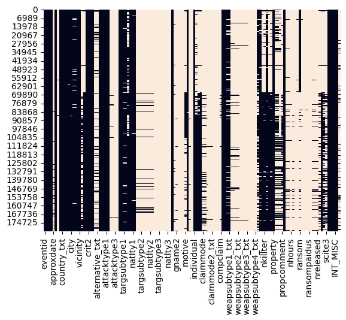

```python
sns.heatmap(df.isnull(), cbar=False)
plt.show()
```

### What did you know about your dataset?

The dataset contains global terrorism incidents from 1970–2017 with features like location, attack type, target, weapon used, casualties, and terrorist groups. It contains many missing values in certain columns like motive and perpetrator details.

## **2. Understanding Your Variables**

```python
df.columns
```

```
Index(['eventid', 'iyear', 'imonth', 'iday', 'approxdate', 'extended',
       'resolution', 'country', 'country_txt', 'region',
       ...
       'addnotes', 'scite1', 'scite2', 'scite3', 'dbsource', 'INT_LOG',
       'INT_IDEO', 'INT_MISC', 'INT_ANY', 'related'],
      dtype='object', length=135)
```

```python
df.describe()
```

|  | eventid | iyear | imonth | iday | extended | country | region | latitude | longitude | specificity | ... | ransomamt | ransomamtus | ransompaid | ransompaidus | hostkidoutcome | nreleased | INT_LOG | INT_IDEO | INT_MISC | INT_ANY |
| --- | --- | --- | --- | --- | --- | --- | --- | --- | --- | --- | --- | --- | --- | --- | --- | --- | --- | --- | --- | --- | --- |
| count | 1.816910e+05 | 181691.000000 | 181691.000000 | 181691.000000 | 181691.000000 | 181691.000000 | 181691.000000 | 177135.000000 | 1.771340e+05 | 181685.000000 | ... | 1.350000e+03 | 5.630000e+02 | 7.740000e+02 | 552.000000 | 10991.000000 | 10400.000000 | 181691.000000 | 181691.000000 | 181691.000000 | 181691.000000 |
| mean | 2.002705e+11 | 2002.638997 | 6.467277 | 15.505644 | 0.045346 | 131.968501 | 7.160938 | 23.498343 | -4.586957e+02 | 1.451452 | ... | 3.172530e+06 | 5.784865e+05 | 7.179437e+05 | 240.378623 | 4.629242 | -29.018269 | -4.543731 | -4.464398 | 0.090010 | -3.945952 |
| std | 1.325957e+09 | 13.259430 | 3.388303 | 8.814045 | 0.208063 | 112.414535 | 2.933408 | 18.569242 | 2.047790e+05 | 0.995430 | ... | 3.021157e+07 | 7.077924e+06 | 1.014392e+07 | 2940.967293 | 2.035360 | 65.720119 | 4.543547 | 4.637152 | 0.568457 | 4.691325 |
| min | 1.970000e+11 | 1970.000000 | 0.000000 | 0.000000 | 0.000000 | 4.000000 | 1.000000 | -53.154613 | -8.618590e+07 | 1.000000 | ... | -9.900000e+01 | -9.900000e+01 | -9.900000e+01 | -99.000000 | 1.000000 | -99.000000 | -9.000000 | -9.000000 | -9.000000 | -9.000000 |
| 25% | 1.991021e+11 | 1991.000000 | 4.000000 | 8.000000 | 0.000000 | 78.000000 | 5.000000 | 11.510046 | 4.545640e+00 | 1.000000 | ... | 0.000000e+00 | 0.000000e+00 | -9.900000e+01 | 0.000000 | 2.000000 | -99.000000 | -9.000000 | -9.000000 | 0.000000 | -9.000000 |
| 50% | 2.009022e+11 | 2009.000000 | 6.000000 | 15.000000 | 0.000000 | 98.000000 | 6.000000 | 31.467463 | 4.324651e+01 | 1.000000 | ... | 1.500000e+04 | 0.000000e+00 | 0.000000e+00 | 0.000000 | 4.000000 | 0.000000 | -9.000000 | -9.000000 | 0.000000 | 0.000000 |
| 75% | 2.014081e+11 | 2014.000000 | 9.000000 | 23.000000 | 0.000000 | 160.000000 | 10.000000 | 34.685087 | 6.871033e+01 | 1.000000 | ... | 4.000000e+05 | 0.000000e+00 | 1.273412e+03 | 0.000000 | 7.000000 | 1.000000 | 0.000000 | 0.000000 | 0.000000 | 0.000000 |
| max | 2.017123e+11 | 2017.000000 | 12.000000 | 31.000000 | 1.000000 | 1004.000000 | 12.000000 | 74.633553 | 1.793667e+02 | 5.000000 | ... | 1.000000e+09 | 1.320000e+08 | 2.750000e+08 | 48000.000000 | 7.000000 | 2769.000000 | 1.000000 | 1.000000 | 1.000000 | 1.000000 |

8 rows × 77 columns

### Variables Description

🗓️ Time-related Variables

iyear: Year in which the terrorist attack occurred.

imonth: Month of the attack (1–12).

iday: Day of the attack.

🌍 Geographical Variables

country_txt: Name of the country where the attack took place.

region_txt: Region of the world (e.g., South Asia, Middle East & North Africa).

provstate: Province or state where the incident occurred. city: City in which the attack happened.

latitude: Latitude coordinate of the incident location.

longitude: Longitude coordinate of the incident location.

💣 Attack Characteristics

attacktype1_txt: Type of terrorist attack (e.g., Bombing, Armed Assault, Hijacking).

targtype1_txt: Type of target attacked (e.g., Civilians, Military, Government).

target1: Specific target description.

weaptype1_txt: Type of weapon used (e.g., Explosives, Firearms).

weapsubtype1_txt: Sub-category of weapon type.

🧠 Perpetrator Information

gname: Name of the terrorist group responsible for the attack.

motive: Known or suspected motive behind the attack (often missing).

⚠️ Casualty & Impact Variables

nkill: Number of people killed in the attack.

nwound: Number of people wounded.

property: Indicates whether property damage occurred (1 = Yes, 0 = No).

propextent_txt: Extent of property damage (e.g., Minor, Major, Catastrophic).

### Check Unique Values for each variable.

```python
df.nunique()
```

```
eventid       181691
iyear             47
imonth            13
iday              32
approxdate      2244
               ...
INT_LOG            3
INT_IDEO           3
INT_MISC           3
INT_ANY            3
related        14306
Length: 135, dtype: int64
```

## 3. **Data Wrangling**

### Data Wrangling Code

```python
# Handling missing values
df['nkill'] = df['nkill'].fillna(0)
df['nwound'] = df['nwound'].fillna(0)

# Dropping irrelevant columns
df = df.drop(['motive'], axis=1, errors='ignore')
```

## **4. Data Vizualization, Storytelling & Experimenting with charts : Understand the relationships between variables**

#### Chart - 1

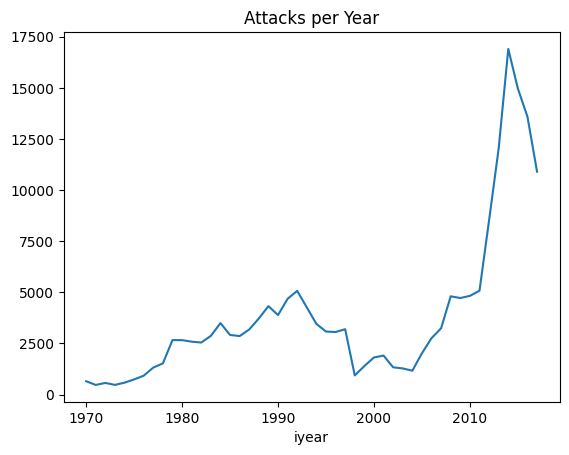

```python
df['iyear'].value_counts().sort_index().plot()
plt.title("Attacks per Year")
plt.show()
```

##### 1. Why did you pick the specific chart?

Trend analysis

##### 2. What is/are the insight(s) found from the chart?

Increase after 2000

##### 3. Will the gained insights help creating a positive business impact?

Are there any insights that lead to negative growth? Justify with specific reason.

#### Chart - 2

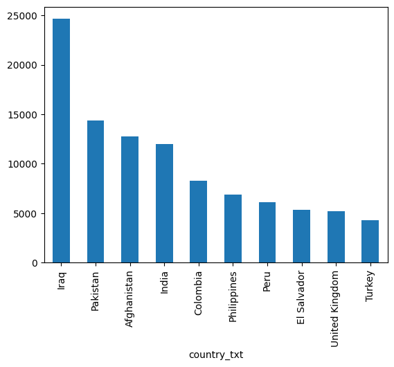

```python
df['country_txt'].value_counts().head(10).plot(kind='bar')
plt.show()
```

##### 1. Why did you pick the specific chart?

Bar charts are ideal for comparing categories. It helps identify which countries face the most attacks.

##### 2. What is/are the insight(s) found from the chart?

Countries like Iraq, Pakistan, and Afghanistan show the highest number of attacks.

##### 3. Will the gained insights help creating a positive business impact?

Are there any insights that lead to negative growth? Justify with specific reason.

Helps policymakers focus resources on high-risk countries. Negative impact: shows regional instability.

#### Chart - 3

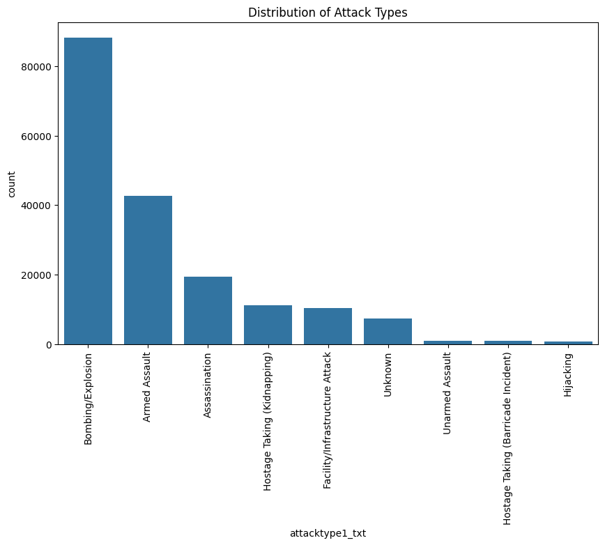

```python
# Chart - 3 visualization code
plt.figure(figsize=(10,6))
sns.countplot(x='attacktype1_txt', data=df, order=df['attacktype1_txt'].value_counts().index)
plt.xticks(rotation=90)
plt.title("Distribution of Attack Types")
plt.show()
```

##### 1. Why did you pick the specific chart?

Countplot is useful for categorical frequency distribution.

##### 2. What is/are the insight(s) found from the chart?

Bombings/explosions are the most common attack types.

##### 3. Will the gained insights help creating a positive business impact?

Are there any insights that lead to negative growth? Justify with specific reason.

Security agencies can focus on explosive detection systems and prevention strategies.

#### Chart - 4

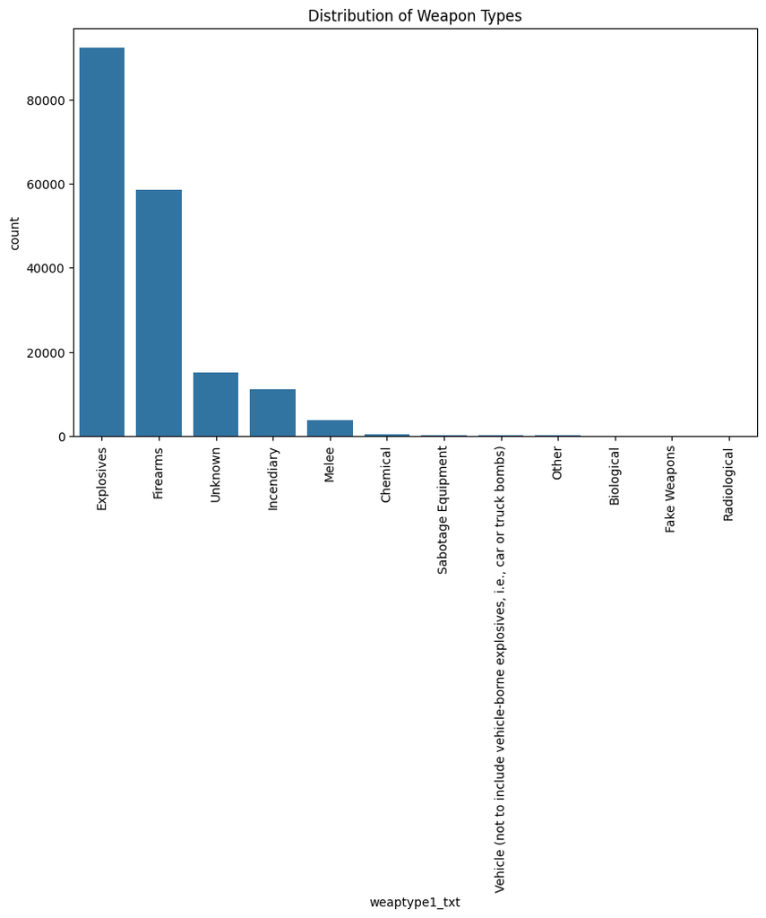

```python
# Chart - 4 visualization code
plt.figure(figsize=(10,6))
sns.countplot(x='weaptype1_txt', data=df, order=df['weaptype1_txt'].value_counts().index)
plt.xticks(rotation=90)
plt.title("Distribution of Weapon Types")
plt.show()
```

##### 1. Why did you pick the specific chart?

this chart is used to analyze categorical data related to weapon types used in attacks.

##### 2. What is/are the insight(s) found from the chart?

Explosives and firearms are the most commonly used weapons in terrorist activities.

##### 3. Will the gained insights help creating a positive business impact?

Are there any insights that lead to negative growth? Justify with specific reason.

Yes, it helps authorities focus on regulating explosive materials and firearms. Negative implication: easy access to such weapons increases attack frequency.

#### Chart - 5

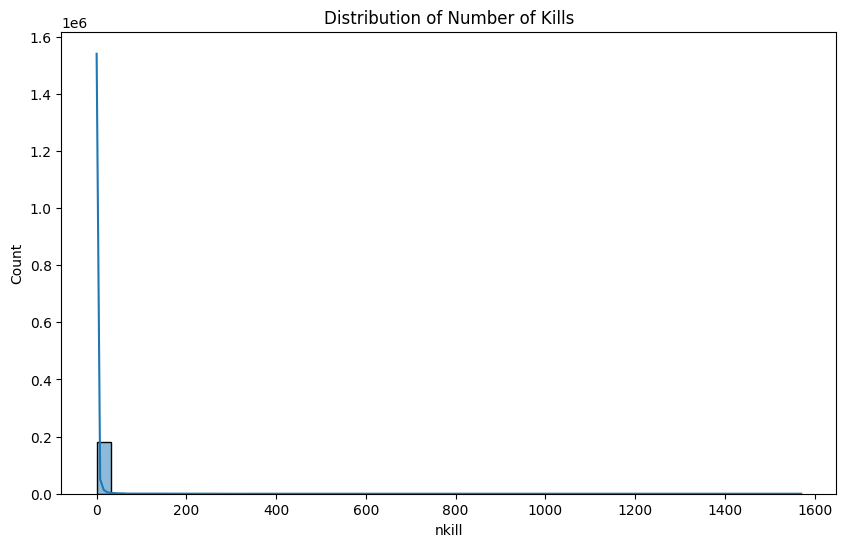

```python
# Chart - 5 visualization code
plt.figure(figsize=(10,6))
sns.histplot(df['nkill'], bins=50, kde=True)
plt.title("Distribution of Number of Kills")
plt.show()
```

##### 1. Why did you pick the specific chart?

Histogram is ideal for understanding the distribution and spread of numerical data.

##### 2. What is/are the insight(s) found from the chart?

Most attacks result in low casualties, but there are a few extreme cases with very high fatalities (outliers).

##### 3. Will the gained insights help creating a positive business impact?

Are there any insights that lead to negative growth? Justify with specific reason.

Yes, helps identify high-risk events and prepare emergency response strategies. Negative: rare but extreme events can cause major instability.

#### Chart - 6

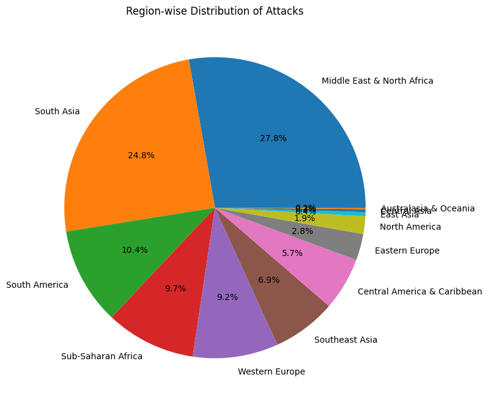

```python
# Chart - 6 visualization code
plt.figure(figsize=(8,8))
df['region_txt'].value_counts().plot.pie(autopct='%1.1f%%')
plt.title("Region-wise Distribution of Attacks")
plt.ylabel('')
plt.show()
```

##### 1. Why did you pick the specific chart?

Pie chart is useful to show proportion of attacks across regions.

##### 2. What is/are the insight(s) found from the chart?

Middle East & South Asia contribute the highest percentage of attacks.\

##### 3. Will the gained insights help creating a positive business impact?

Are there any insights that lead to negative growth? Justify with specific reason.

Yes, helps in allocating security resources region-wise. Negative: highlights geopolitical instability in certain regions.

#### Chart - 7

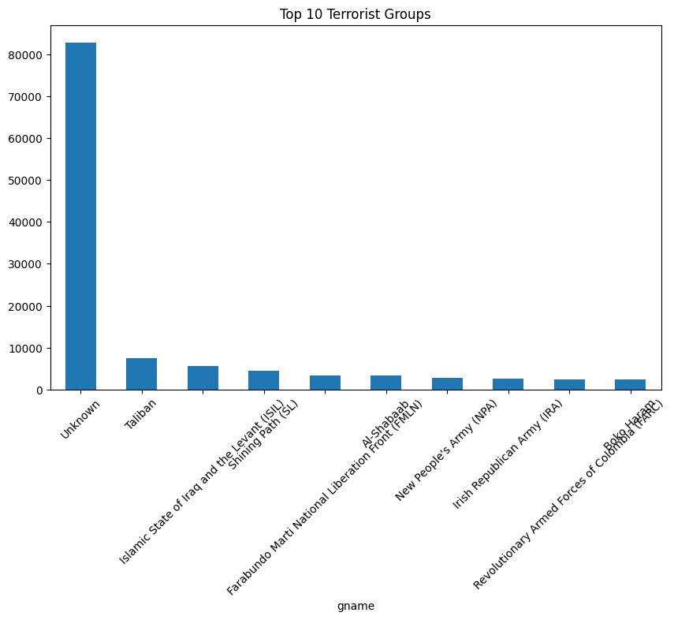

```python
# Chart - 7 visualization code
plt.figure(figsize=(10,6))
df['gname'].value_counts().head(10).plot(kind='bar')
plt.title("Top 10 Terrorist Groups")
plt.xticks(rotation=45)
plt.show()
```

##### 1. Why did you pick the specific chart?

Bar chart is best for comparing top categories.

##### 3. Will the gained insights help creating a positive business impact?

Are there any insights that lead to negative growth? Justify with specific reason.

Yes, intelligence agencies can target major groups for disruption. This insight supports focused counter-terrorism strategies

#### Chart - 8

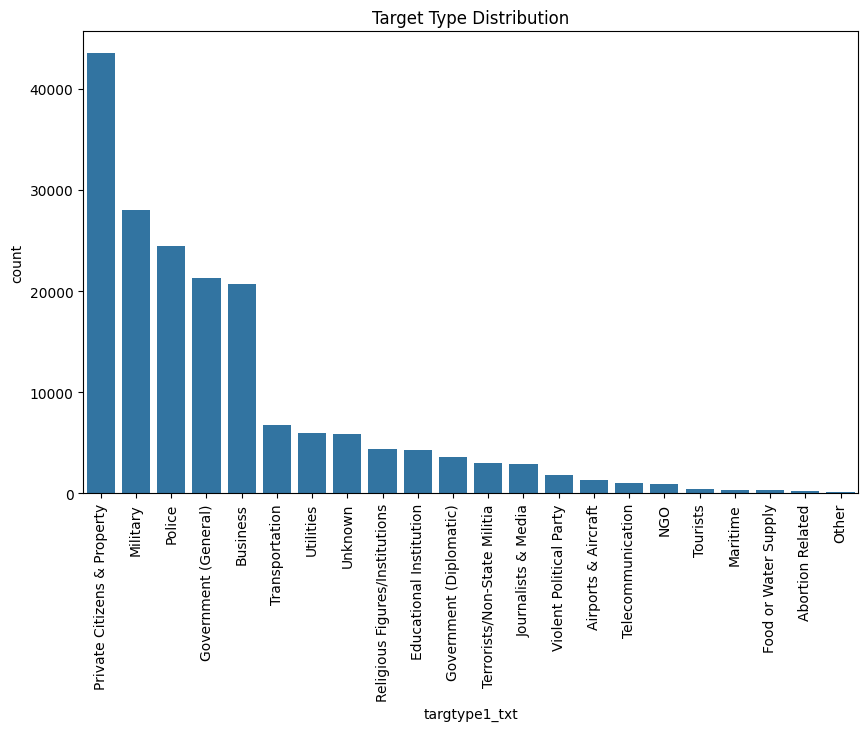

```python
# Chart - 8 visualization code
plt.figure(figsize=(10,6))
sns.countplot(x='targtype1_txt', data=df, order=df['targtype1_txt'].value_counts().index)
plt.xticks(rotation=90)
plt.title("Target Type Distribution")
plt.show()
```

##### 1. Why did you pick the specific chart?

Used to analyze categorical target types attacked.

##### 2. What is/are the insight(s) found from the chart?

Civilians, military, and police are the most frequent targets.

##### 3. Will the gained insights help creating a positive business impact?

Are there any insights that lead to negative growth? Justify with specific reason.

Yes, helps strengthen protection for vulnerable targets. Negative: high targeting of civilians indicates social instability.

#### Chart - 9

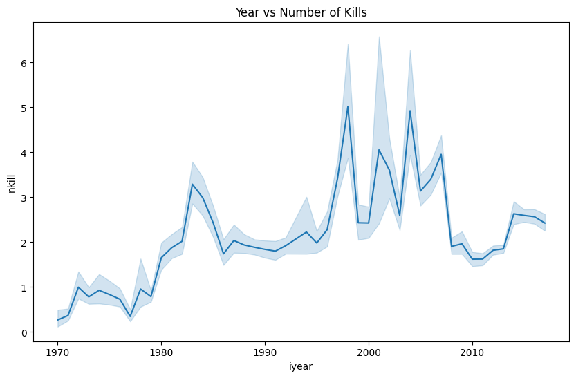

```python
# Chart - 9 visualization code
plt.figure(figsize=(10,6))
sns.lineplot(x='iyear', y='nkill', data=df)
plt.title("Year vs Number of Kills")
plt.show()
```

##### 1. Why did you pick the specific chart?

Line chart helps analyze trends over time.

##### 2. What is/are the insight(s) found from the chart?

Certain years show spikes in casualties, indicating major incidents.

##### 3. Will the gained insights help creating a positive business impact?

Are there any insights that lead to negative growth? Justify with specific reason.

Yes, helps identify peak danger periods. Useful for predictive modeling and proactive security planning.

#### Chart - 10

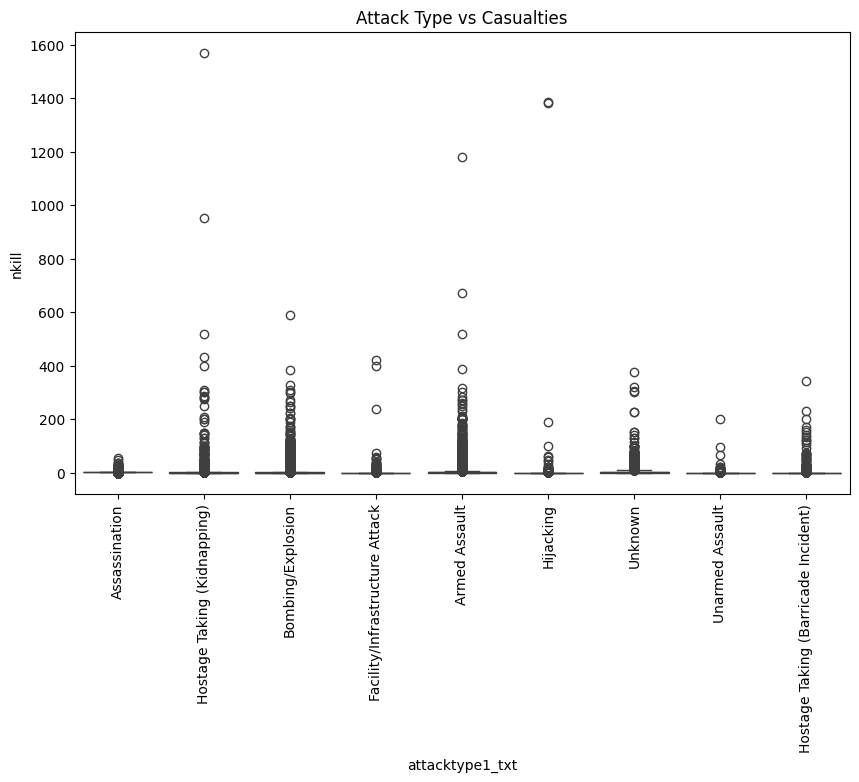

```python
# Chart - 10 visualization code
plt.figure(figsize=(10,6))
sns.boxplot(x='attacktype1_txt', y='nkill', data=df)
plt.xticks(rotation=90)
plt.title("Attack Type vs Casualties")
plt.show()
```

##### 1. Why did you pick the specific chart?

Boxplot shows distribution and outliers across categories.

##### 3. Will the gained insights help creating a positive business impact?

Are there any insights that lead to negative growth? Justify with specific reason.

Yes, helps prioritize prevention strategies. Focus can be placed on high-impact attack types.

#### Chart - 11

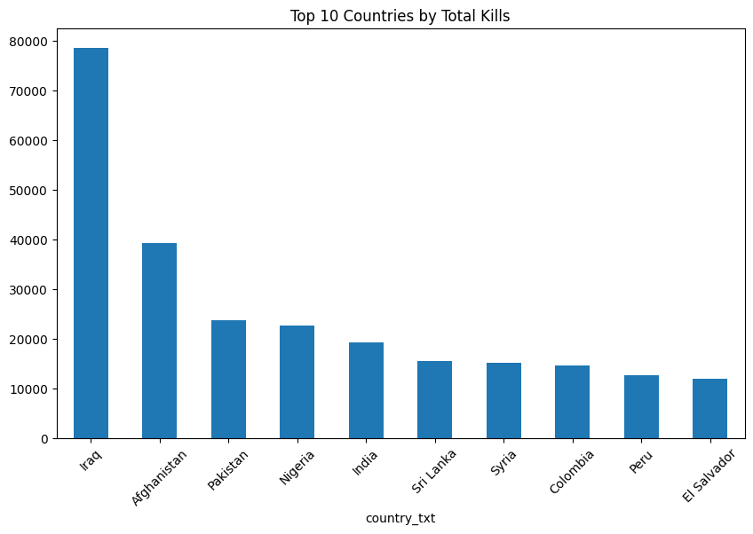

```python
# Chart - 11 visualization code
top_countries = df.groupby('country_txt')['nkill'].sum().sort_values(ascending=False).head(10)

plt.figure(figsize=(10,6))
top_countries.plot(kind='bar')
plt.title("Top 10 Countries by Total Kills")
plt.xticks(rotation=45)
plt.show()
```

##### 1. Why did you pick the specific chart?

Bar chart is used to compare total casualties across countries.

##### 2. What is/are the insight(s) found from the chart?

Some countries experience both high attack frequency and high fatalities.

##### 3. Will the gained insights help creating a positive business impact?

Are there any insights that lead to negative growth? Justify with specific reason.

Yes, helps identify most affected countries. Useful for international policy and aid allocation.

#### Chart - 12

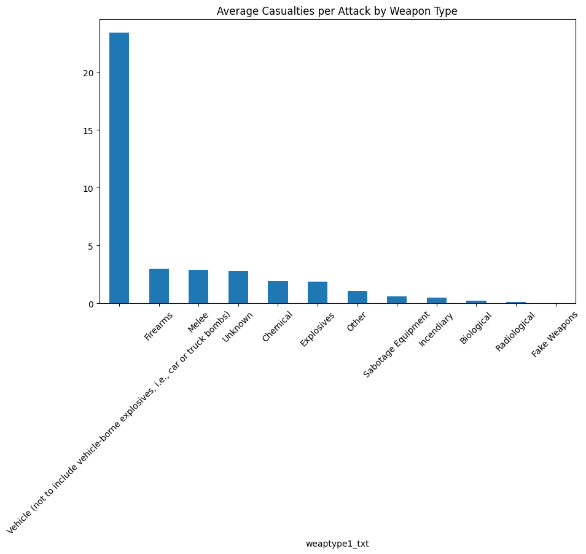

```python
# Chart - 12 visualization code
weapon_kills = df.groupby('weaptype1_txt')['nkill'].mean().sort_values(ascending=False)

plt.figure(figsize=(10,6))
weapon_kills.plot(kind='bar')
plt.title("Average Casualties per Attack by Weapon Type")
plt.xticks(rotation=45)
plt.show()
```

##### 1. Why did you pick the specific chart?

This chart is used to measure the effectiveness of different weapon types by analyzing average casualties per attack, rather than just frequency.

##### 3. Will the gained insights help creating a positive business impact?

Are there any insights that lead to negative growth? Justify with specific reason.

#### Chart - 13

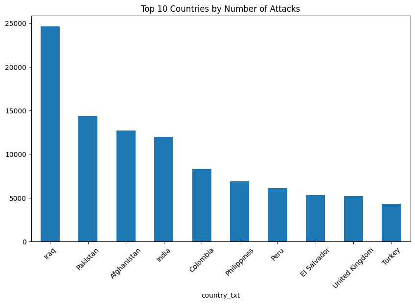

```python
# Chart - 13 visualization code
top_countries = df['country_txt'].value_counts().head(10)

plt.figure(figsize=(10,6))
top_countries.plot(kind='bar')
plt.title("Top 10 Countries by Number of Attacks")
plt.xticks(rotation=45)
plt.show()
```

##### 1. Why did you pick the specific chart?

Bar chart helps compare attack frequency across countries and identify concentration.

##### 3. Will the gained insights help creating a positive business impact?

Are there any insights that lead to negative growth? Justify with specific reason.

Yes, resources can be strategically concentrated in high-risk countries instead of being evenly distributed. This leads to more efficient security planning.

#### Chart - 14 - Correlation Heatmap

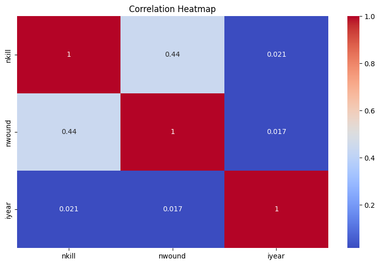

```python
# Chart - 14 visualization code
plt.figure(figsize=(10,6))
sns.heatmap(df[['nkill','nwound','iyear']].corr(), annot=True, cmap='coolwarm')
plt.title("Correlation Heatmap")
plt.show()
```

##### 1. Why did you pick the specific chart?

A heatmap is ideal for understanding relationships between multiple numerical variables at once.

#### Chart - 15 - Pair Plot

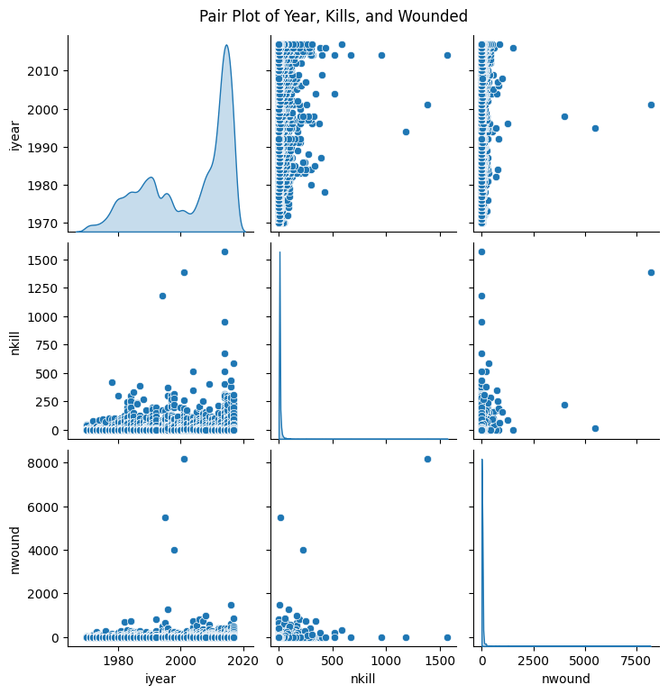

```python
# Chart - 15 visualization code

# Selecting important numerical columns
selected_cols = ['iyear', 'nkill', 'nwound']

# Pair Plot
plt.figure(figsize=(10,6))
sns.pairplot(df[selected_cols], diag_kind='kde')

plt.suptitle("Pair Plot of Year, Kills, and Wounded", y=1.02)
plt.show()
```

##### 1. Why did you pick the specific chart?

A pair plot is used to visualize pairwise relationships between multiple numerical variables simultaneously. It provides both scatter plots for relationships and distribution plots for individual variables, making it highly effective for multivariate analysis. In this case, variables like year (iyear), number of kills (nkill), and number of wounded (nwound) are selected to understand their interactions and patterns.

## **5. Solution to Business Objective**

#### What do you suggest the client to achieve Business Objective ?

Explain Briefly.

Based on the comprehensive analysis of the global terrorism dataset, several strategic recommendations can be made to help stakeholders such as governments, security agencies, and international organizations effectively address and mitigate terrorist threats.

Firstly, the analysis reveals that terrorist activities are highly concentrated in specific regions and countries rather than being evenly distributed. Therefore, a focused resource allocation strategy should be adopted, where maximum security efforts, funding, and intelligence operations are directed toward high-risk regions such as the Middle East and South Asia. This ensures optimal utilization of limited resources.

Additionally, the presence of a small number of highly active terrorist groups suggests that counter-terrorism strategies should shift from reactive policing to intelligence-driven operations. Tracking and dismantling these networks can significantly reduce overall attack frequency.

The analysis also highlights temporal patterns and peak periods of attacks, which can be leveraged to build predictive models. These models can help anticipate future threats and allow proactive deployment of security forces.

Finally, the identification of long-tail risk patterns, where rare events cause massive damage, emphasizes the importance of dual strategies:

Managing frequent low-scale attacks Preparing for rare high-impact catastrophic events

Overall, adopting a data-driven, targeted, and proactive approach will significantly enhance the effectiveness of counter-terrorism measures and contribute to global security.

# **Conclusion**

This project successfully conducted an in-depth exploratory data analysis of global terrorism data spanning several decades, uncovering critical patterns and insights related to the nature, distribution, and impact of terrorist activities.

The analysis demonstrates that terrorism is not random but follows identifiable patterns across time, geography, and strategy. A significant rise in attacks after the year 2000 highlights the evolving nature of global conflicts, while the concentration of incidents in specific regions confirms the presence of persistent geopolitical instability.

One of the key takeaways is the existence of concentration effects and long-tail distributions, where a small number of regions and events account for a large portion of overall impact. This highlights the importance of targeted interventions and preparedness for rare but catastrophic incidents.

Moreover, the project emphasizes the importance of data-driven decision-making in addressing complex global challenges. By leveraging analytical techniques and visualization, it becomes possible to transform raw data into actionable insights that can support strategic planning and policy formulation.

In conclusion, this analysis provides a strong foundation for predictive analytics, risk assessment, and proactive security planning. With further integration of machine learning models, these insights can be extended to build intelligent systems capable of forecasting and preventing future threats, ultimately contributing to a safer and more secure world.